# CPLN675_HW3_CGYEDM

Alex & Sean

3/30/2022

Climate Resilience is an important, but neglected, field of City Planning. Developing a climate action plan can be just as important to a city as a economic, housing, and community plan.

For Calgary in 2013, their neglect to perform substantial flood preventative measures caught up to the city. The June 2013 floods hit Calgary hard as the city is at the meeting point of multiple rivers. So the abnormally large snow melt flooded the city’s downtown – causing approximately $409 million in infrastructure damages. [[source](https://www.calgary.ca/uep/water/flood-info/flooding-history-calgary.html)]

For this project, we set out to understand where Calagary’s Flood Hazard areas are then understand which factors contribute the most to those hazards. As a comparison, this project will also use Calgary’s neighbor, Edmonton, as they are compareable in size.

This report will be structure in this format:

**1. Data Import & Visualizations** *– City Area, Water, Flood Hazards, Elevation*

**2. Feature Engineering** *– Topology, Water Distances, Soil Types*

**3. Logistic Model** *– Fitting, Summary*

**4. Results** *– Cut-Off Threshold, ROC Curve, Confusion Matrix & Maps*

**5. Conclusions**

# 1. Data Import & Visualizations

In order to best predict which areas will flood in Calgary & Edmonton, we will (1) pull in reference data, (2) elevations, (3) the flood hazard zones themselves, and then (4) attach them to fishnets.

A majority of this data comes from the Province of Alberta’s [Open Data portal](https://geodiscover.alberta.ca/geoportal/#searchPanel), and their private contractor, [Altalis](https://www.altalis.com/). A more in-depth list of our data can be found in our [Google Sheet](https://docs.google.com/spreadsheets/d/1C52FlmWvJtl7u7BU0SqG903enKzIkzxjlgL7Sgc4NpA/edit?usp=sharing).

## 1.1 Reference Data

```r
proj_crs = st_crs(file.path(DATA_PATH,'Alberta_Projection.prj'))

pather = function(focus_paths){
  focus_paths = paste(c(focus_paths), collapse='/')
  final_path = paste(DATA_PATH, focus_paths, sep='/')
  return(final_path)
  }

# # GRIDS
# ## ALBERTA TOWNSHIP SURVEY SYSTEM's SUBDIVISIONS -- 1/16 square mile grid
# ## https://www.alberta.ca/alberta-township-survey-system.aspx
# GRIDS_PATH = file.path(DATA_PATH, 'clean_data/grids')
#
# ## CALGARY
# GRID_NAME = 'CGY_GRIDS.shp'
# #GRID_NAME = 'CGY_sub_0625mi.shp'
# cgy.grid = st_read(file.path(GRIDS_PATH, GRID_NAME)) %>%
#   st_transform(proj_crs) %>%
#   st_make_valid()
#
# ## EDMONTON
# GRID_NAME = 'EDM_GRIDS.shp'
# #GRID_NAME = 'EDM_sub_0625mi.shp'
# edm.grid = st_read(file.path(GRIDS_PATH, GRID_NAME)) %>%
#   st_transform(proj_crs) %>%
#   st_make_valid()

# CITY BOUNDARIES & BOUNDARY BOXES (~10mi away from city boundaries)
## function to add

REF_PATH = 'raw_data/reference'
BOUND_PATH = file.path(DATA_PATH, 'clean_data/boundaries')


get_bound = function(name) {
  file.path(BOUND_PATH, name) %>%
    st_read() %>%
    st_transform(proj_crs)
}
## CALGARY
cgy.bbox =
  st_read(pather(c(REF_PATH, 'cgy_bbox.shp'))) %>%
  # reduce by 3 miles
  st_buffer(-4828.03) %>%
  st_make_grid(., n=1) %>%
  st_sf()
cgy.bound = get_bound('CGY_citybound.shp')
## EDMONTON
edm.bbox =
  st_read(pather(c(REF_PATH, 'edm_bbox.shp'))) %>%
  # reduce by 3 miles
  st_buffer(-4828.03) %>%
  st_make_grid(., n=1) %>%
  st_sf()
edm.bound = get_bound('EDM_citybound.shp')
```

```r
WATER_PATH = pather(c(REF_PATH, 'alberta_water.shp'))
WATER_ALL_PATH = pather(c(REF_PATH, 'alberta_water_all.shp'))

alta.water = st_read(WATER_PATH) %>% st_transform(proj_crs)
cgy.water = alta.water %>% st_intersection(cgy.bbox)
edm.water = alta.water %>% st_intersection(edm.bbox)
rm(alta.water)

alta.water.all = st_read(WATER_ALL_PATH) %>% st_transform(proj_crs)
cgy.water.all = alta.water.all %>% st_intersection(cgy.bbox)
edm.water.all = alta.water.all %>% st_intersection(edm.bbox)
rm(alta.water.all)
```

Our two project areas of Calgary & Edmonton can be seen in Map 1.1. With the map having the same scale, it is apparent that they share a few similarities in: 1. Shape 2. Geographic Size 3. Orientation around a Major River

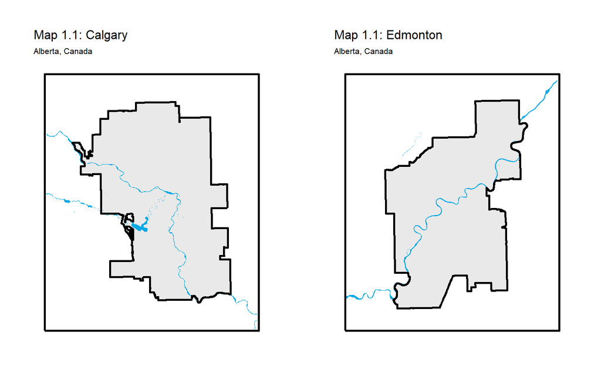

```r
geom_bound = function(data=cgy.bbox, color = 'black', lwd=1, fill=NA, ...){
  geom_sf(data=data,color=color,lwd=lwd,fill=fill,...)
}

geom_edm_bbox = function(data=edm.bbox, color = 'black', lwd=1, fill=NA, ...){geom_bound(data,color,lwd,fill,...)}
geom_cgy_bbox = function(data=cgy.bbox, color = 'black', lwd=1, fill=NA, ...){geom_bound(data,color,lwd,fill,...)}
geom_edm_bound = function(data=edm.bound, color = 'black', lwd=1, fill=NA, ...){geom_bound(data,color,lwd,fill,...)}
geom_cgy_bound = function(data=cgy.bound, color = 'black', lwd=1, fill=NA, ...){geom_bound(data,color,lwd,fill,...)}


water_color = '#00A9E6'

edm_plot =
  ggplot() +
  geom_edm_bound(fill='lightgrey', alpha=.5) +
  geom_sf(data=edm.water, fill='#00A9E6', color=NA) +
  geom_edm_bound() +
  geom_edm_bbox() +
  labs(title = "Map 1.1: Edmonton", subtitle='Alberta, Canada') +
  mapTheme

cgy_plot =
  ggplot() +
  geom_cgy_bound(fill='lightgrey', alpha=.5) +
  geom_sf(data=cgy.water, fill='#00A9E6', color=NA) +
  geom_cgy_bound() +
  geom_cgy_bbox() +
  labs(title = "Map 1.1: Calgary", subtitle='Alberta, Canada') +
  mapTheme

ggarrange(
  cgy_plot,
  edm_plot,
  ncol=2,
  common.legend = TRUE,
  legend = 'right'
)
```

## 1.2 Digital Elevation Model

The city’s elevations, in Map 1.2, negate the geographic similarities in the last map. Calgary has a much higher overall elevation and sits at the foothills of the Rocky Mountains. Although Edmonton is 183 miles Northeast of Calgary, it sits 500 meters lower than than its southern neighbor. Not to mention that Edmonton is relatively flat. I had to configure the breaks so that you see at least two elevation breaks in the Edmonton map.

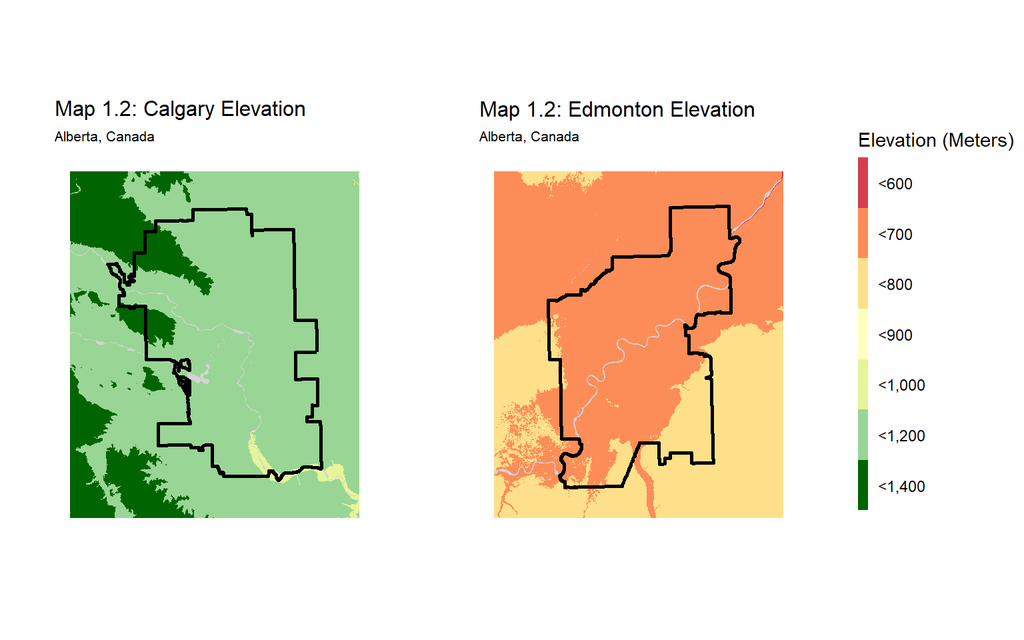

```r
# IMPORT
DEM_PATH = 'raw_data/dem'

CGY_DEM_PATH = pather(c(DEM_PATH, 'cgy_dem_100m.tif'))
cgy.dem.100 =
    raster(CGY_DEM_PATH) %>%
    crop(., cgy.bbox)

EDM_DEM_PATH = pather(c(DEM_PATH, 'edm_dem_100m.tif'))
edm.dem.100 = raster(EDM_DEM_PATH) %>%
    crop(., edm.bbox)

Spectral6 = c("#d53e4f","#fc8d59","#fee08b","#e6f598","#99d594","#3288bd")
Spectral7 = c("#d53e4f","#fc8d59","#fee08b","#ffffbf","#e6f598","#99d594","darkgreen")#"#3288bd")

pbreaks = c(0, 600, 700, 800, 900, 1000, 1200, 3000)
plabs = c('<600', '<700', '<800', '<900', '<1,000', '<1,200', '<1,400')
pColors = Spectral7

ggarrange(
  ggplot() +
    geom_raster(data=rast(cgy.dem.100),
                aes(x,y,fill=as.factor(cut(value, breaks=pbreaks)))
                ) +
    geom_sf(data=cgy.water, fill='lightgrey', color=NA) +
    scale_fill_manual(values = pColors,
                    labels=plabs,
                   name="Elevation (Meters)",
                   drop = FALSE
                   ) +
    geom_cgy_bound() +
    labs(title = "Map 1.2: Calgary Elevation", subtitle='Alberta, Canada') +
    mapTheme,
  ggplot() +
    geom_raster(data=rast(edm.dem.100),
                aes(x,y,fill=as.factor(cut(value, breaks=pbreaks)))
                ) +
    geom_sf(data=edm.water, fill='lightgrey', color=NA) +
    scale_fill_manual(values = pColors,
                    labels=plabs,
                   name="Elevation (Meters)",
                   drop = FALSE
                   ) +
    geom_edm_bound() +
    labs(title = "Map 1.2: Edmonton Elevation", subtitle='Alberta, Canada') +
    mapTheme,
  ncol=2,
  common.legend = TRUE,
  legend = 'right'
)
```

## 1.3 Flood Hazards

Although Edmonton has a sizeable flood hazard in the Northeast section of the city, it is at a slight lower elevation and located outside the main city area. So even if Edmonton’s single river flooded, it narrow and deep enough to mitigate the damages.

[figure not shown]

```r
FLOOD_PATH = pather(c(REF_PATH, 'alberta_floodhazard.shp'))
cgy.flood = st_read(FLOOD_PATH) %>% st_intersection(cgy.bbox)
edm.flood = st_read(FLOOD_PATH) %>% st_intersection(edm.bbox)

edm_plot =
  ggplot() +
  geom_edm_bound(fill='lightgrey', alpha=.5) +
  geom_sf(data=edm.flood, aes(fill=Multi_Zone), color=NA) +
  geom_sf(data=edm.water, fill='#00A9E6', color=NA) +
  geom_edm_bound() +
  geom_edm_bbox() +
  scale_fill_manual(values = c('salmon','red','maroon'),name="Flood Zone Types") +
  labs(title = "Map 1.3: Edmonton Flood Zones", subtitle='Alberta, Canada') +
  mapTheme

cgy_plot =
  ggplot() +
  geom_cgy_bound(fill='lightgrey', alpha=.5) +
  geom_sf(data=cgy.flood, aes(fill=Multi_Zone), color=NA) +
  geom_sf(data=cgy.water, fill='#00A9E6', color=NA) +
  geom_cgy_bound() +
  geom_cgy_bbox() +
  scale_fill_manual(values = c('salmon','red','maroon'),name="Flood Zone Types") +
  labs(title = "Map 1.4: Calgary Flood Zones", subtitle='Alberta, Canada') +
  mapTheme

ggarrange(
  cgy_plot,
  edm_plot,
  ncol=2,
  common.legend = TRUE,
  legend = 'right'
)
```

```r
cgy.flood =
  rbind(
    cgy.flood %>% dplyr::select(geometry),
    cgy.water %>% dplyr::select(geometry)
    ) %>%
  st_union() %>%
  st_sf() %>%
  mutate(flood=1)
edm.flood =
  rbind(
    edm.flood %>% dplyr::select(geometry),
    edm.water %>% dplyr::select(geometry)
    ) %>%
  st_union() %>%
  st_sf() %>%
  mutate(flood=1)
```

## 1.4 Fishnets

With Calgary’s more concerning flood hazards, we will join all of this stated data to fishnets. The fishnets are 100m by 100m cells that are based on the DEM’s raster. This allows the elevation to easily compare to other features we create.

```r
cgy.fish =
  cgy.dem.100 %>%
  raster_to_fishnet(.) %>%
  rownames_to_column("id.fishnet") %>%
  mutate(id.fishnet = as.numeric(id.fishnet)) %>%
  st_sf(., crs=proj_crs) %>%
  rename(dem_100m = cgy_dem_100m)

edm.fish =
  edm.dem.100 %>%
  raster_to_fishnet(.) %>%
  rownames_to_column("id.fishnet") %>%
  mutate(id.fishnet = as.numeric(id.fishnet)) %>%
  st_sf(., crs=proj_crs) %>%
  rename(dem_100m = edm_dem_100m)
```

```r
edm.empty_raster = edm.dem.100
edm.empty_raster[] = NA

cgy.empty_raster = cgy.dem.100
cgy.empty_raster[] = NA

st_rasterize = function(focus_sf, empty_raster){
  focus_sf %>%
  as(.,'Spatial') %>%
  rasterize(., empty_raster)
}

edm.flood.rast = st_rasterize(edm.flood, edm.empty_raster)
edm.flood.rast[is.na(edm.flood.rast)] = 0

cgy.flood.rast = st_rasterize(cgy.flood, cgy.empty_raster)
cgy.flood.rast[is.na(cgy.flood.rast)] = 0

# add raster to col
add_raster_as_col = function(
  # raster
  focus_raster,
  # focus col to rename in raster
  # & add to focus_fishnet as column
  focus_col,
  focus_fishnet){
  st_join(
    focus_fishnet %>% dplyr::select(geometry),
    focus_raster %>%
      raster_to_centroid() %>%
      rename_first_col(.,focus_col)
    ) %>%
    st_drop_geometry() %>%
    pull(focus_col)
}

edm.fish$flood =
  add_raster_as_col(edm.flood.rast, 'flood', edm.fish)
cgy.fish$flood =
 add_raster_as_col(cgy.flood.rast, 'flood', cgy.fish)
```

Map 1.4 highlights these flood hazards as fishnet cells, rather than the winding vector shapes. Whether of not the cell is a flood indundation zone, will be the dependent variable of our logistic regression in Section 3.

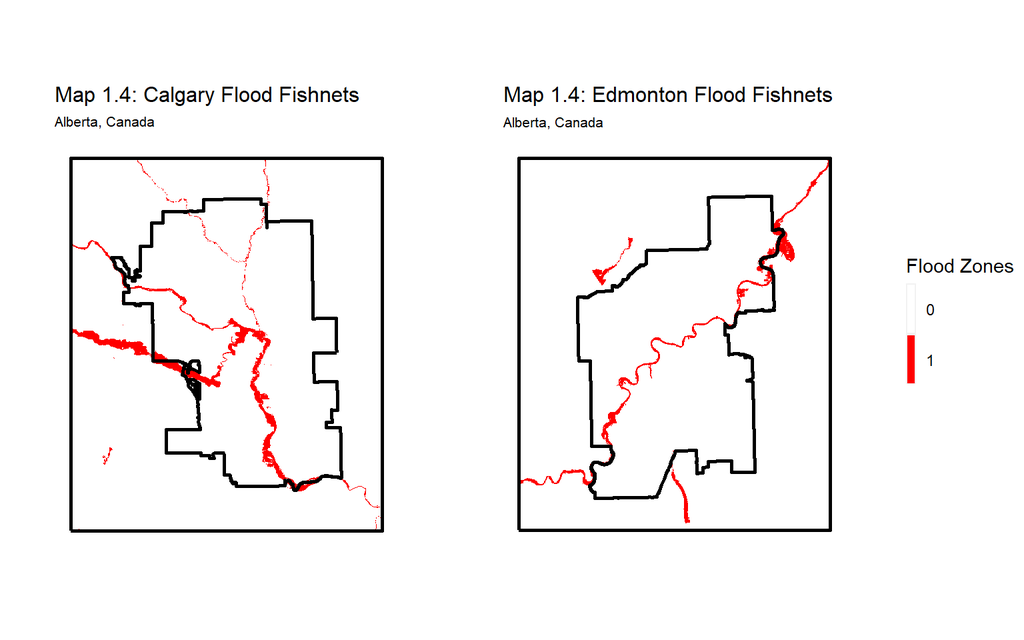

```r
colors2 = c('white', 'red')

edm_plot =
  ggplot() +
  geom_edm_bound(fill='lightgrey', alpha=.5) +
  geom_sf(data=edm.fish, aes(fill=as.factor(flood)), color=NA) +
  geom_edm_bound() +
  geom_edm_bbox() +
  scale_fill_manual(values = colors2,name="Flood Zones") +
  labs(title = "Map 1.4: Edmonton Flood Fishnets", subtitle='Alberta, Canada') +
  mapTheme

cgy_plot =
  ggplot() +
  geom_cgy_bound(fill='lightgrey', alpha=.5) +
  geom_sf(data=cgy.fish, aes(fill=as.factor(flood)), color=NA) +
  geom_cgy_bound() +
  geom_cgy_bbox() +
  scale_fill_manual(values = colors2,name="Flood Zones") +
  labs(title = "Map 1.4: Calgary Flood Fishnets", subtitle='Alberta, Canada') +
  mapTheme

ggarrange(
  cgy_plot,
  edm_plot,
  ncol=2,
  common.legend = TRUE,
  legend = 'right'
)
```

# 2. Feature Engineering

Before modeling, this section will try to form other features that can predict flooding. In this project, we will be looking at topological formations, distances to water, and soil types.

## 2.1 Topology

For topology features, we will be looking at the cell’s slope, flow direction, and the aspect (defining which direction the slope is pointed).

```r
# 1. slope
cgy.slope = terrain(cgy.dem.100, opt = 'slope', unit = 'degrees')
# 2. water flow
cgy.flow = terrain(cgy.dem.100, opt="flowdir", neighbors=8)
# 3. aspect/orientation
cgy.aspect = terrain(cgy.dem.100, opt = "aspect", unit = "degrees")
# 4. Topographic Position Index (TPI) of elevation
## difference between the [elevation] of a cell and the mean [elevation] of its 8 surrounding cells
cgy.tpi = terrain(cgy.dem.100, opt = "tpi")
# 5. Terrain Ruggedness Index (TRI) of elevation
## the mean of the absolute differences between the [elevation] of a cell and the [elevation] of its 8 surrounding cells
cgy.tri = terrain(cgy.dem.100, opt = "tri")
# 6. Roughness of elevation
## the difference between the maximum and the minimum [elevation] of a cell and its 8 surrounding cells
cgy.rough = terrain(cgy.dem.100, opt = "roughness")

# 1. slope
edm.slope = terrain(edm.dem.100, opt = 'slope', unit = 'degrees')
# 2. water flow
edm.flow = terrain(edm.dem.100, opt="flowdir", neighbors=8)
# 3. aspect/orientation
edm.aspect = terrain(edm.dem.100, opt = "aspect", unit = "degrees")
# 4. Topographic Position Index (TPI) of elevation
## difference between the [elevation] of a cell and the mean [elevation] of its 8 surrounding cells
edm.tpi = terrain(edm.dem.100, opt = "tpi")
# 5. Terrain Ruggedness Index (TRI) of elevation
## the mean of the absolute differences between the [elevation] of a cell and the [elevation] of its 8 surrounding cells
edm.tri = terrain(edm.dem.100, opt = "tri")
# 6. Roughness of elevation
## the difference between the maximum and the minimum [elevation] of a cell and its 8 surrounding cells
edm.rough = terrain(edm.dem.100, opt = "roughness")

cgy.slope[is.na(cgy.slope)]=0
cgy.fish$topo.slope =
  add_raster_as_col(cgy.slope, 'slope', cgy.fish)
cgy.flow[is.na(cgy.flow)]=0
cgy.fish$topo.flow =
  add_raster_as_col(cgy.flow, 'flow', cgy.fish)
cgy.aspect[is.na(cgy.aspect)]=0
cgy.fish$topo.aspect =
  add_raster_as_col(cgy.aspect, 'aspect', cgy.fish)

edm.slope[is.na(edm.slope)]=0
edm.fish$topo.slope =
  add_raster_as_col(edm.slope, 'slope', edm.fish)
edm.flow[is.na(edm.flow)]=0
edm.fish$topo.flow =
  add_raster_as_col(edm.flow, 'flow', edm.fish)
edm.aspect[is.na(edm.aspect)]=0
edm.fish$topo.aspect =
  add_raster_as_col(edm.aspect, 'aspect', edm.fish)
```

Calgary & Edmonton’s aspects help reinforce the downhill direction and canyons. Calgary’s Westerly canyons & streams funnel towards the center of the city then exit to the south. Edmonton’s single river cuts through the city in a Northeasterly direction.

[figure not shown]

```r
cgy_plot1 =
  ggplot() +
  geom_raster(data=rast(cgy.slope),aes(x,y,fill=value)) +
  geom_cgy_bbox() +
  geom_cgy_bound() +
  scale_fill_viridis(option = "D", name='') +
  labs(title='Map 2.1A: Calgary Slope') +
  mapTheme +
  guides(color = guide_legend(override.aes = list(size = 0.5)))

cgy_plot2 =
  ggplot() +
  geom_raster(data=rast(cgy.flow),aes(x,y,fill=value)) +
  geom_cgy_bbox() +
  geom_cgy_bound() +
  scale_fill_viridis(option = "A", name='') +
  labs(title='Map 2.1B: Calgary Flow') +
  mapTheme +
  guides(color = guide_legend(override.aes = list(size = 0.5)))

cgy_plot3 =
  ggplot() +
  geom_raster(data=rast(cgy.aspect),aes(x,y,fill=value)) +
  geom_cgy_bbox() +
  geom_cgy_bound() +
  scale_fill_viridis(option = "A", name='') +
  labs(title='Map 2.1C: Calgary Aspect') +
  mapTheme +
  guides(color = guide_legend(override.aes = list(size = 0.5)))

edm_plot1 =
  ggplot() +
  geom_raster(data=rast(edm.slope),aes(x,y,fill=value)) +
  geom_edm_bbox() +
  geom_edm_bound() +
  scale_fill_viridis(option = "D", name='') +
  labs(title='Map 2.1B: Edmonton Slope') +
  mapTheme +
  guides(color = guide_legend(override.aes = list(size = 0.5)))

edm_plot2 =
  ggplot() +
  geom_raster(data=rast(edm.flow),aes(x,y,fill=value)) +
  geom_edm_bbox() +
  geom_edm_bound() +
  scale_fill_viridis(option = "A", name='') +
  labs(title='Map 2.1E: Edmonton Flow') +
  mapTheme +
  guides(color = guide_legend(override.aes = list(size = 0.5)))

edm_plot3 =
  ggplot() +
  geom_raster(data=rast(edm.aspect),aes(x,y,fill=value)) +
  geom_edm_bbox() +
  geom_edm_bound() +
  scale_fill_viridis(option = "A", name='') +
  labs(title='Map 2.1F: Edmonton Aspect') +
  mapTheme +
  guides(color = guide_legend(override.aes = list(size = 0.5)))

ggarrange(
  cgy_plot1,
  cgy_plot2,
  cgy_plot3,
  edm_plot1,
  edm_plot2,
  edm_plot3
)
```

## 2.2 Water Distances

Another important consideration is how far areas are to water. Map 2.2 shows that the cities appear to have the same amount of close distances to water. However, Calgary’s distances emphasize that most areas are close to a major river or stream. Edmonton has more lakes, leading to semingly shorter distances. But the lakes could potentially capture more flood water

```r
cgy.water.raster = st_rasterize(cgy.water.all, cgy.empty_raster)
cgy.water.raster[is.na(cgy.water.raster)] = 0
cgy.fish$water =
  add_raster_as_col(cgy.water.raster, 'water', cgy.fish)

edm.water.raster = st_rasterize(edm.water.all, edm.empty_raster)
edm.water.raster[is.na(edm.water.raster)] = 0
edm.fish$water =
  add_raster_as_col(edm.water.raster, 'water', edm.fish)

cgy.fish$water.dist =
  st_distance(
    st_centroid(cgy.fish),
    st_cast(cgy.water$geometry, "LINESTRING") %>%
      st_union() %>%
      st_as_sf()
  ) %>%
  as.numeric()

edm.fish$water.dist =
  st_distance(
    st_centroid(edm.fish),
    st_cast(edm.water$geometry, "LINESTRING") %>%
      st_union() %>%
      st_as_sf()
  ) %>%
  as.numeric()
```

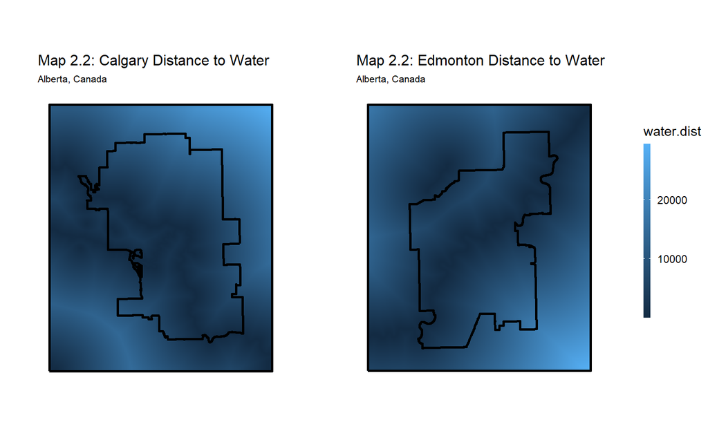

```r
edm_plot =
  ggplot() +
  geom_edm_bound(fill='lightgrey', alpha=.5) +
  geom_sf(data=edm.fish, aes(fill=water.dist), color=NA) +
  geom_edm_bound() +
  geom_edm_bbox() +
  labs(title = "Map 2.2: Edmonton Distance to Water", subtitle='Alberta, Canada') +
  mapTheme

cgy_plot =
  ggplot() +
  geom_cgy_bound(fill='lightgrey', alpha=.5) +
  geom_sf(data=cgy.fish, aes(fill=water.dist), color=NA) +
  geom_cgy_bound() +
  geom_cgy_bbox() +
  labs(title = "Map 2.2: Calgary Distance to Water", subtitle='Alberta, Canada') +
  mapTheme

ggarrange(
  cgy_plot,
  edm_plot,
  ncol=2,
  common.legend = TRUE,
  legend = 'right'
)
```

## 2.3 Sandy Soil Types

```r
alta.soils =
  pather(c('raw_data/sand_and_gravel', 'sand_and_gravel_proj.shp')) %>%
  st_read(.)
cgy.soils = alta.soils %>% st_intersection(cgy.bbox)%>%
  mutate(
    soil_materials = ifelse(
      MATERIAL=="Sand and silt", 'soil.sand_silt',
      ifelse(
        MATERIAL=="Sand, silt and clay, minor gravel", 'soil.sand_silt_clay',
        "soil.sand_gravel"
      )))
edm.soils = alta.soils %>% st_intersection(edm.bbox) %>%
  mutate(
    soil_materials = ifelse(
      MATERIAL=="Sand and silt", 'soil.sand_silt',
      ifelse(
        MATERIAL=="Sand, silt and clay, minor gravel", 'soil.sand_silt_clay',
        "soil.sand_gravel"
      )))


get_soil_type = function(main_soils, material_type, empty_raster, focus_fish){
  focus_soils = main_soils %>%
    filter(soil_materials==material_type) %>%
    st_union() %>% st_sf() %>%
    mutate(value=1) %>% dplyr::select(value)

  focus_soil_raster = st_rasterize(focus_soils, empty_raster)
  focus_soil_raster[is.na(focus_soil_raster)] = 0
  return(add_raster_as_col(focus_soil_raster, material_type, focus_fish))}

material_types = edm.soils$soil_materials %>% unique()
for(material_type in material_types){
  edm.fish[[material_type]] =
    get_soil_type(edm.soils, material_type, edm.empty_raster, edm.fish)
}
material_types = cgy.soils$soil_materials %>% unique()
for(material_type in material_types){
  cgy.fish[[material_type]] =
    get_soil_type(cgy.soils, material_type, cgy.empty_raster, cgy.fish)
}
```

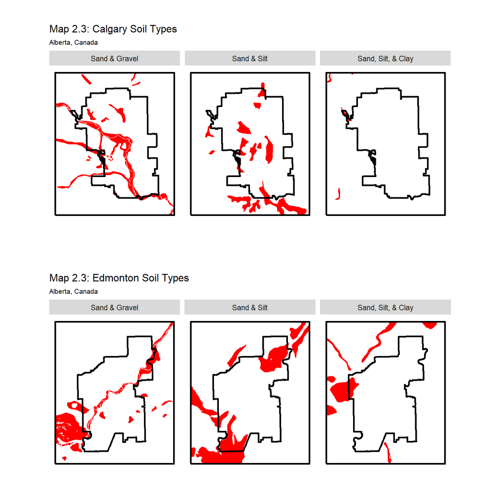

```r
edm_plot =
  edm.fish %>%
    dplyr::select(soil.sand_silt, soil.sand_gravel, soil.sand_silt_clay) %>%
    transmute(
      `Sand & Gravel` = soil.sand_gravel,
      `Sand & Silt` = soil.sand_silt,
      `Sand, Silt, & Clay` = soil.sand_silt_clay
    ) %>%
    gather(Variable, Value, -geometry) %>%
    ggplot(.) +
      geom_sf(
        aes(fill=as.factor(Value)),
        color=NA) +
      geom_edm_bbox() +
      geom_edm_bound() +
      facet_wrap(~Variable) +
      scale_fill_manual(values = c('#FFFFFF','red'),
                          labels=c("","Soil Type"),
                          name="") +
      labs(title="Map 2.3: Edmonton Soil Types", subtitle="Alberta, Canada") +
      mapTheme +
      theme(legend.position="none")

cgy_plot =
  cgy.fish %>%
    dplyr::select(soil.sand_silt, soil.sand_gravel, soil.sand_silt_clay) %>%
    transmute(
      `Sand & Gravel` = soil.sand_gravel,
      `Sand & Silt` = soil.sand_silt,
      `Sand, Silt, & Clay` = soil.sand_silt_clay
    ) %>%
    gather(Variable, Value, -geometry) %>%
    ggplot(.) +
      geom_sf(
        aes(fill=as.factor(Value)),
        color=NA) +
      geom_cgy_bbox() +
      geom_cgy_bound() +
      facet_wrap(~Variable) +
      scale_fill_manual(values = c('#FFFFFF','red'),
                          labels=c("","Soil Type"),
                          name="") +
      labs(title="Map 2.3: Calgary Soil Types", subtitle="Alberta, Canada") +
      mapTheme +
      theme(legend.position="none")

ggarrange(
  cgy_plot,
  edm_plot,
  ncol=1
)
```